# Visualization and Uncertainty

Susan Vanderplas

2025-08-03

# Why Visualization?

## Why Visualization?

[figure not shown]

$$\begin{align*}
L(\alpha_i, \beta_i | y_{i,\boldsymbol{n}_i}) = \prod_{j=1}^{n_i} \frac{\beta_i^{\alpha_i}}{\Gamma(\alpha_i)} y_{ij}^{\alpha_i - 1} \text{exp}(-\beta_i y_{ij})&\end{align*}$$

$$\hat\alpha_i, \hat\beta_i$$

[figure not shown]

## Why Visualization?

- Communicate information about data
  - Doesn’t (always) require statistics knowledge  
    $\Rightarrow$ helpful with the general public
- Visualization uses *higher bandwidth channels* than text

## Higher Bandwidth

### What Helps More?

###### Full Data

| x | y |
| --- | --- |
| 22.3077 | 57.1795 |
| 22.3077 | 61.7949 |
| 23.0769 | 66.4103 |
| 23.3333 | 52.9487 |
| 25.8974 | 51.0256 |
| 26.1538 | 71.4103 |
| 28.9744 | 74.4872 |
| 29.4872 | 51.0256 |
| 29.7436 | 32.1795 |
| 29.7436 | 36.0256 |

[output cut: 132 more lines]

###### Summary Stats

| Stat | x | y |
| --- | --- | --- |
| mean | 54.26 | 47.83 |
| sd | 16.77 | 26.94 |

###### A Plot

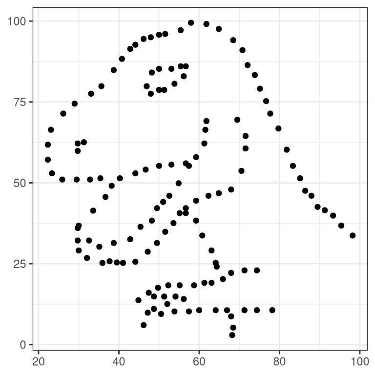

## Why Visualization?

- Communicate information about data
  - Doesn’t (always) require statistics knowledge  
    $\Rightarrow$ helpful with the general public
- Visualization uses *higher bandwidth channels* than e.g. tables
- Well designed graphics can be a form of  
  external cognition

# Making Good Graphics

## Visualization Design Principles

Map your most important variables to more accurate channels

1. Position - common scale (BEST)
2. Position - nonaligned scale
3. Length, direction, angle
4. Area
5. Volume, curvature
6. Shading, color (WORST)

(Cleveland, 1984; Heer and Bostock, 2009)

## Preattentive Perception

- Combinations of preattentive features require attention
  - Double-encoding (using multiple features for the same variable) is ok

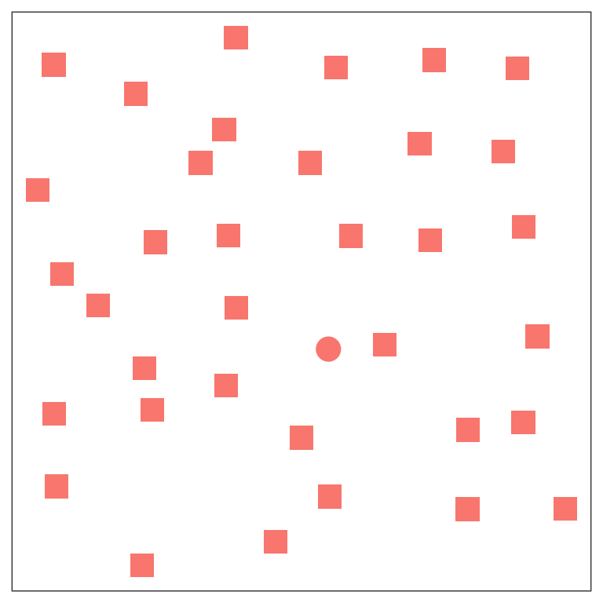

Figure 1: Shape

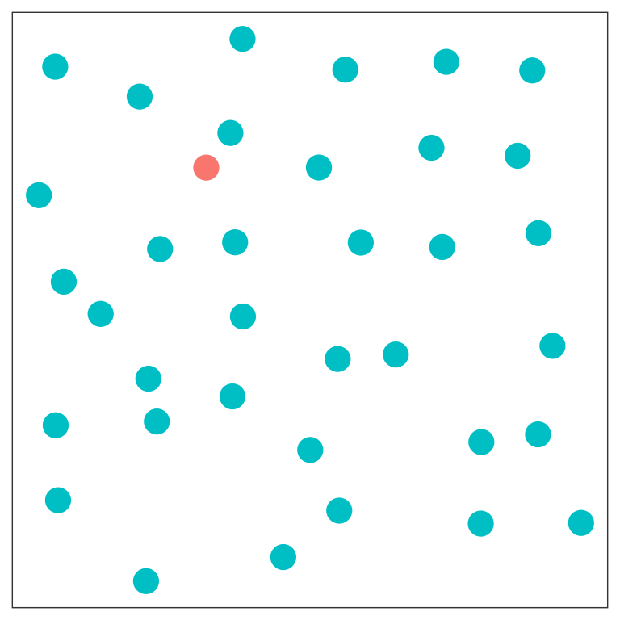

Figure 2: Color

## Preattentive Perception

- Combinations of preattentive features require attention
  - Double-encoding (using multiple features for the same variable) is ok

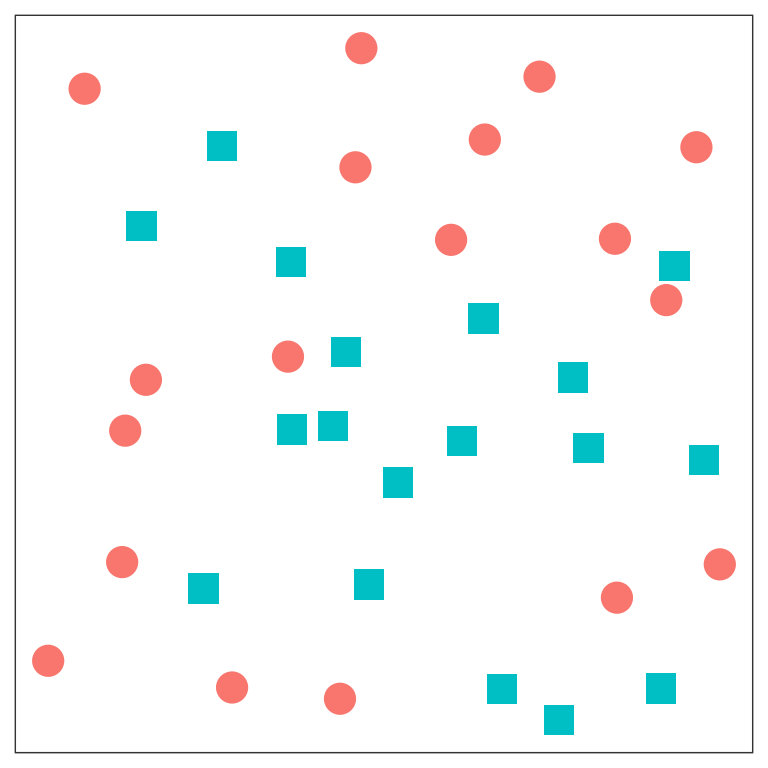

Figure 3: Shape and Color (dual encoded)

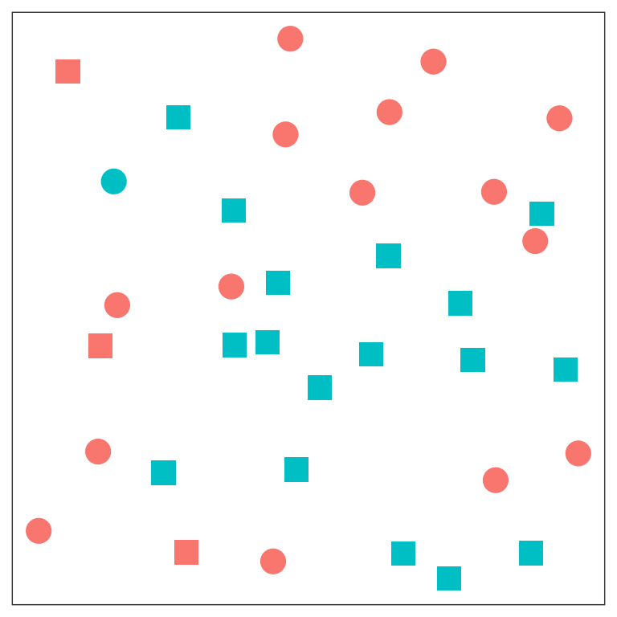

Figure 4: Shape and Color (different variables)

## Grouping in Charts

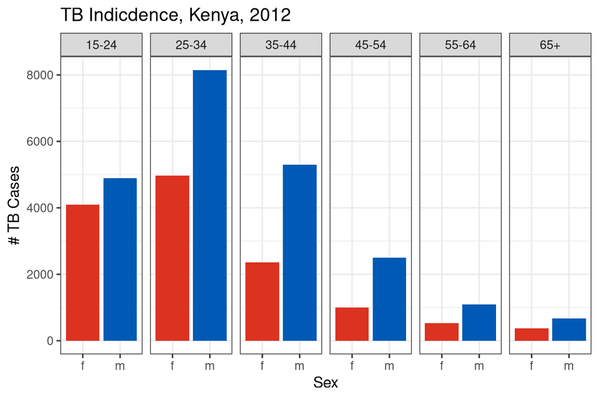

- Compare TB diagnoses by gender for each age

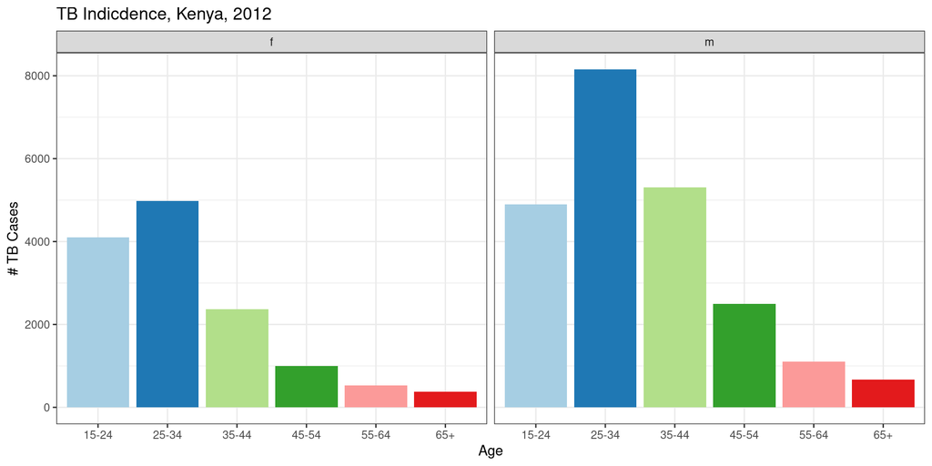

- Compare TB diagnoses within ages for each gender

## Leveraging Associations

[XKCD Color Survey](https://blog.xkcd.com/2010/05/03/color-survey-results/) - Fully saturated color names

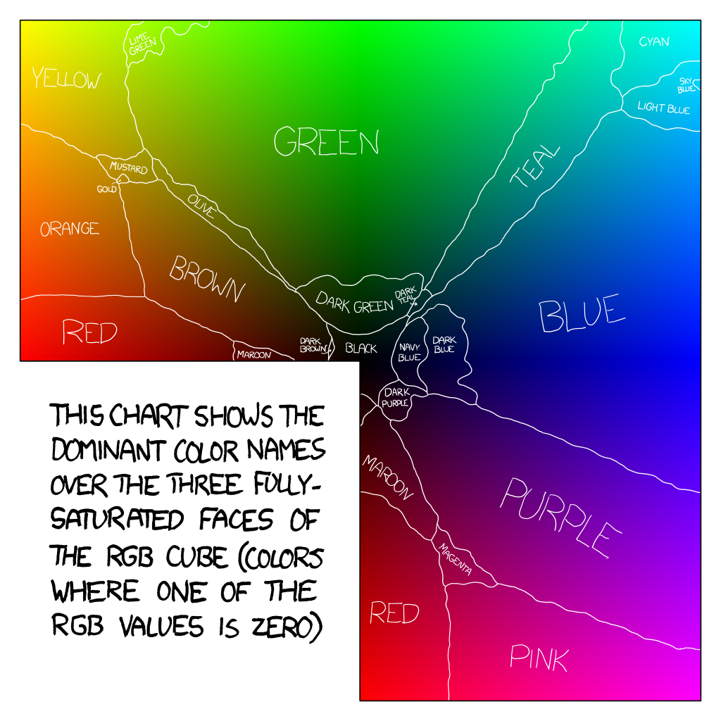

## Leveraging Associations

[XKCD Color Survey](https://blog.xkcd.com/2010/05/03/color-survey-results/) - Fully saturated color names

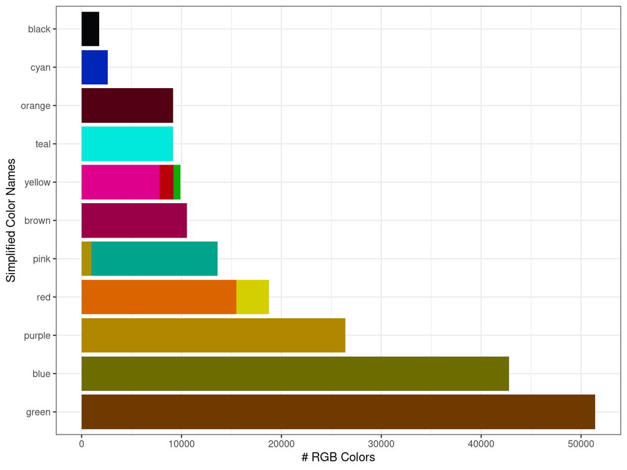

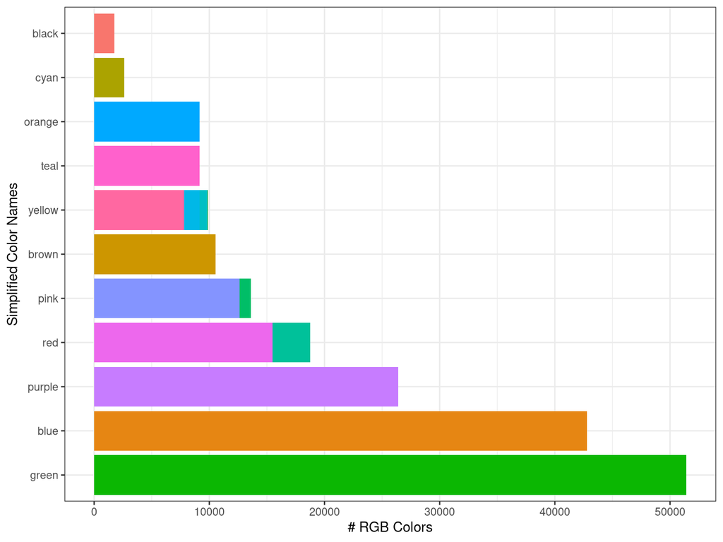

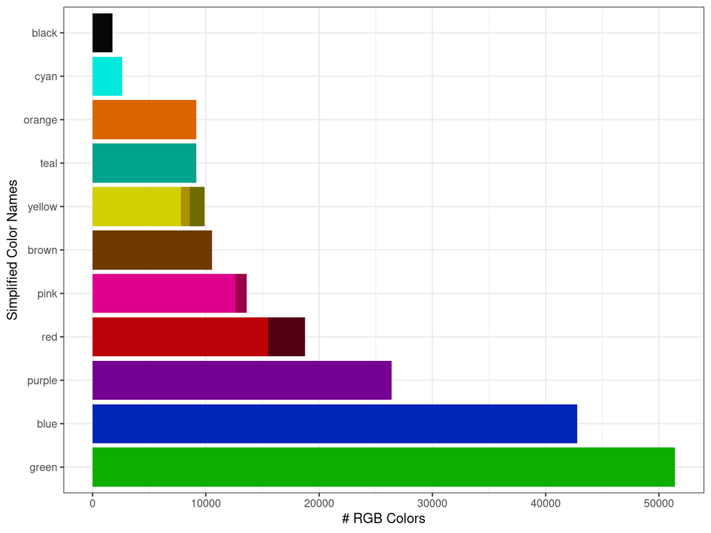

## Leveraging Associations

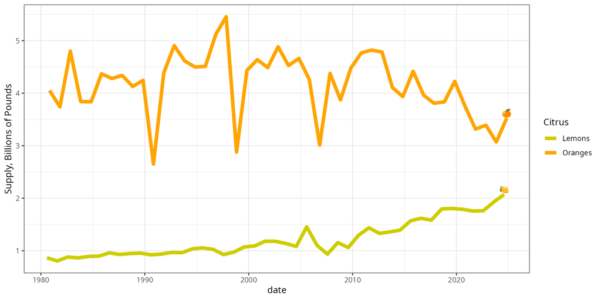

## Leveraging Associations

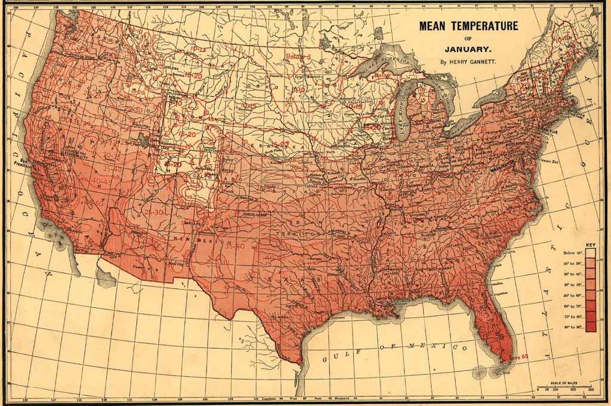

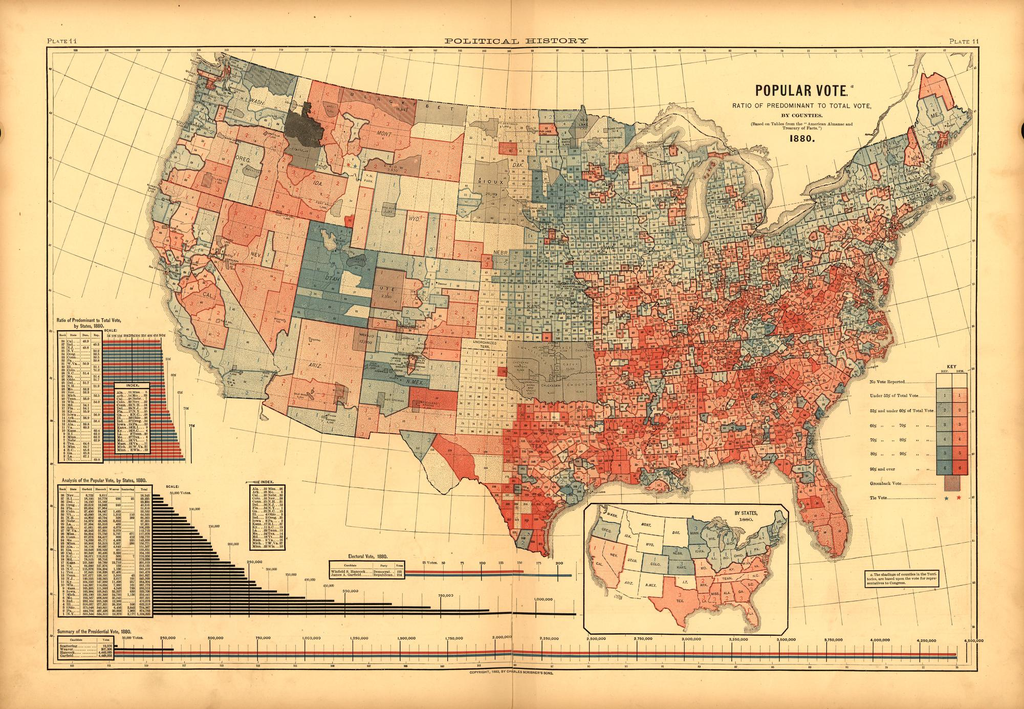

## Know Your Audience

- Associations are audience and culture dependent
  - Victorian era colors: pink was for males, blue for females
- Rates of color deficiency - 10% of males, 0.2% of females
- 🚦Stoplight color schemes are standard for some industries 😭

# What Do You See?

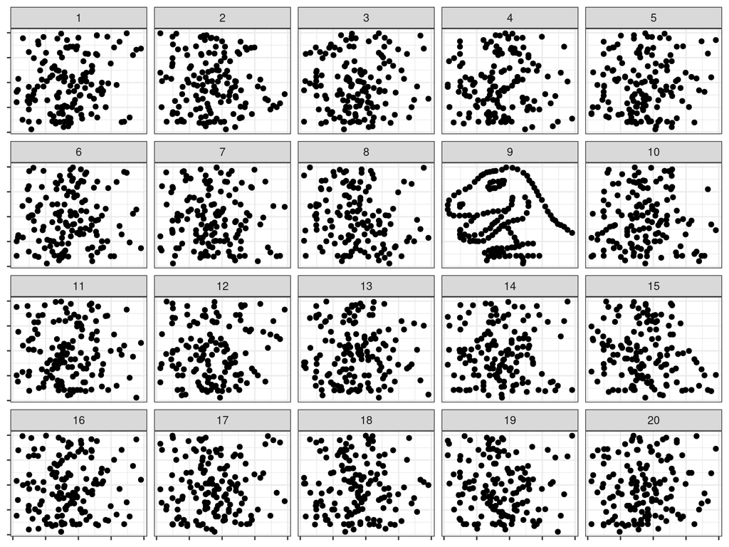

## Which One Is Not Like the Others?

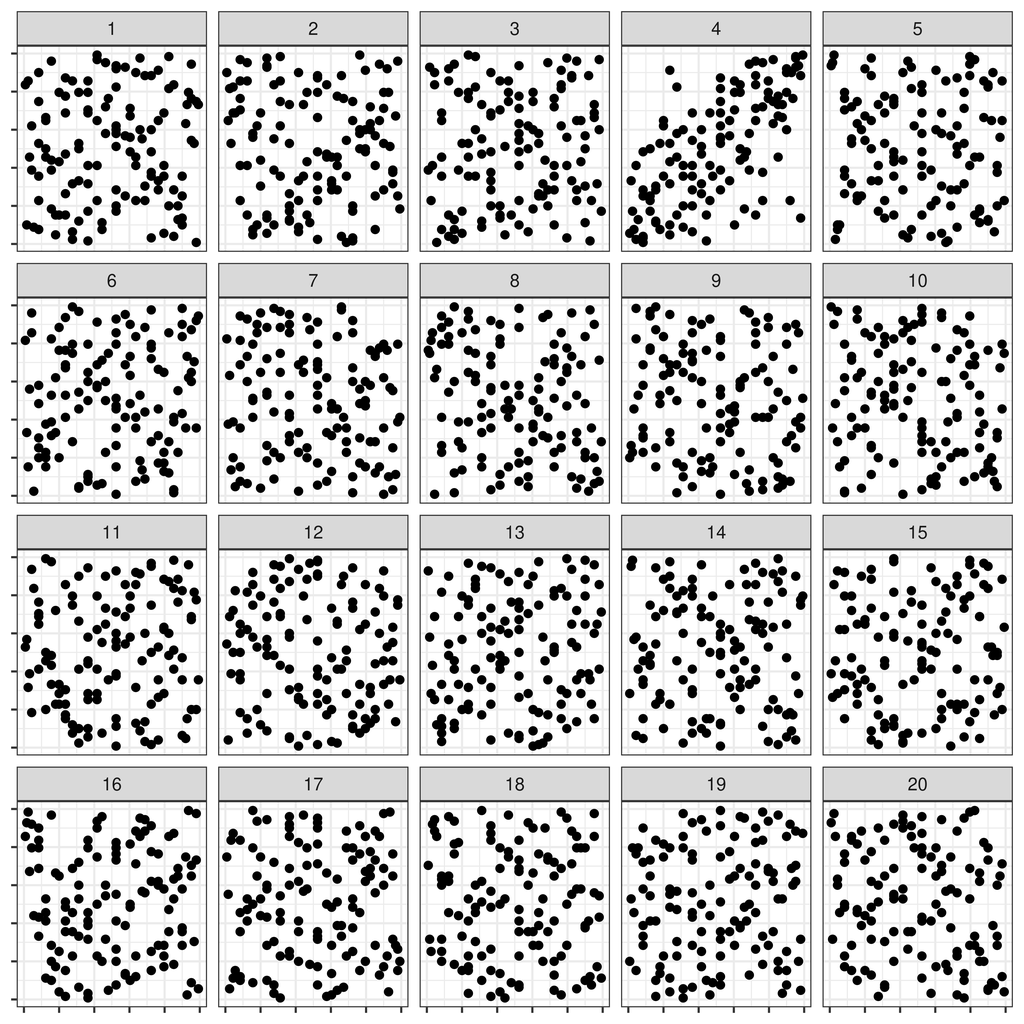

## Statistics and Charts

A **statistic** is a quantity  
🔲computed from values in a sample  
🔲used for a statistical purpose [Wikipedia](https://en.wikipedia.org/wiki/Statistic)

$$\overline{x} = \frac{1}{n}\sum_{i=1}^n x_i$$

A **chart** is a graphical representation for data visualization, in which the data is represented by symbols [Wikipedia](https://en.wikipedia.org/wiki/Chart)

Charts are

✅ computed from values in a sample

✅ used for a statistical purpose

So… charts **are** statistics!

## Testing Statistics

Data from [Tidy Tuesday, 2020-09-01](https://github.com/rfordatascience/tidytuesday/blob/master/data/2020/2020-09-01/readme.md)

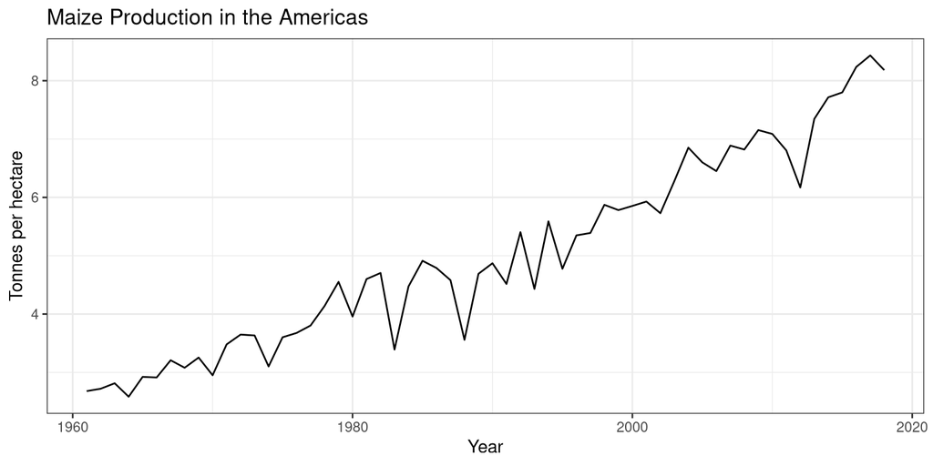

## Testing Statistics

- If statistics are charts, then what is the reference distribution?
- What constitutes an “extreme” or “significant” chart?

## Testing Statistics

Hypothesis testing:

- take a sample
- calculate a test statistic
- compare test statistic to reference distribution  
  (formed by $H_0$)
- if it is unlikely, reject null hypothesis

Visual hypothesis testing:

- take a sample
- create a test chart
- compare chart to a reference distribution of others generated under $H_0$
- if test chart “stands out” then reject null hypothesis

## Testing Statistics

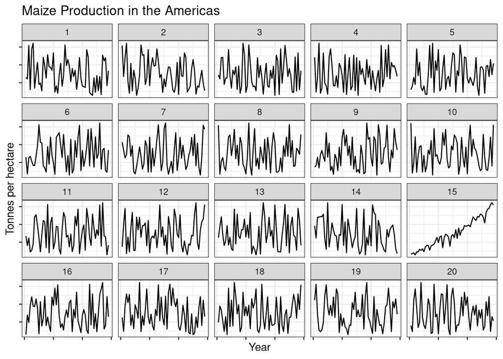

## Testing Statistics

- Plot: A **statistical lineup**
- Method: **visual inference**  
  (graphical hypothesis test)
- Many factors influence the results
  - the data
  - the plot type
  - the plot aesthetics  
    (color, shape, etc.)
  - extra statistical features  
    trend lines, error bars

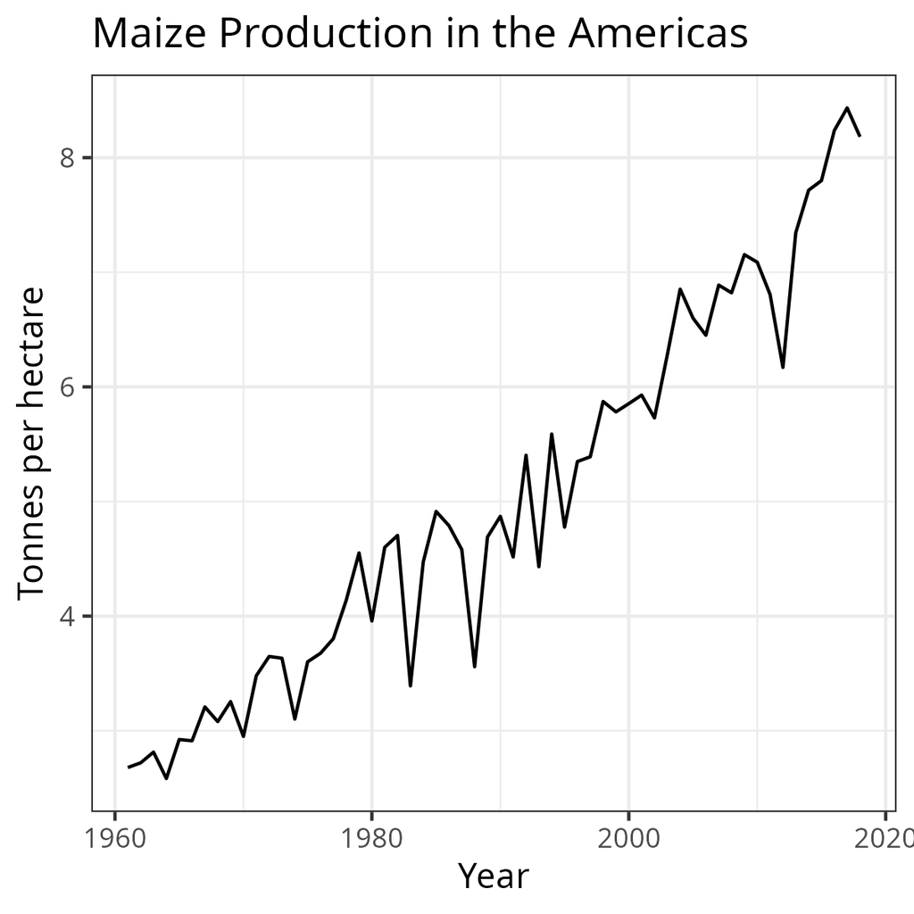

## Visualizing Uncertainty

Data ->

Graphics ->

Graphical Testing ->

Graphical Significance

One method for incorporating and assessing uncertainty with charts

Uncertainty is an inherent property  
of data and statistics -  
it is not easily separated or contained.

# Uncertainty Visualization ❓🫨 📐

## Goal(s) of Uncertainty Visualization

Communicate the Legitimacy of Conclusions

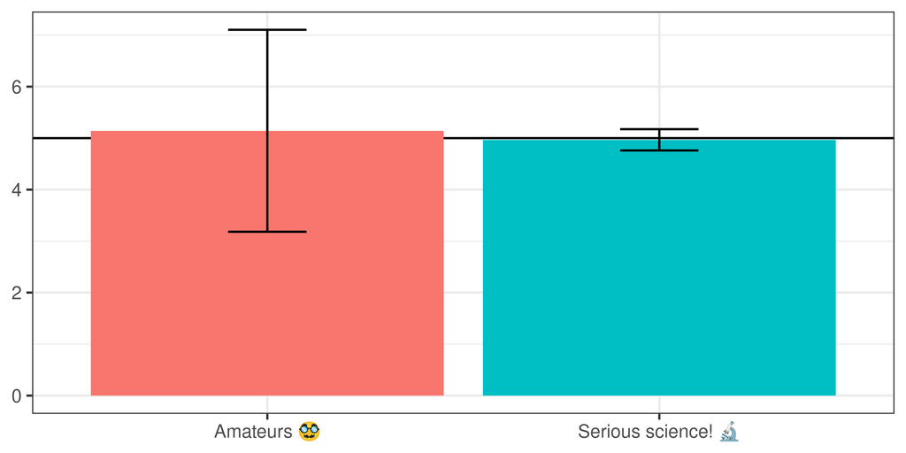

## Goal(s) of Uncertainty Visualization

Communicate the Legitimacy of Conclusions

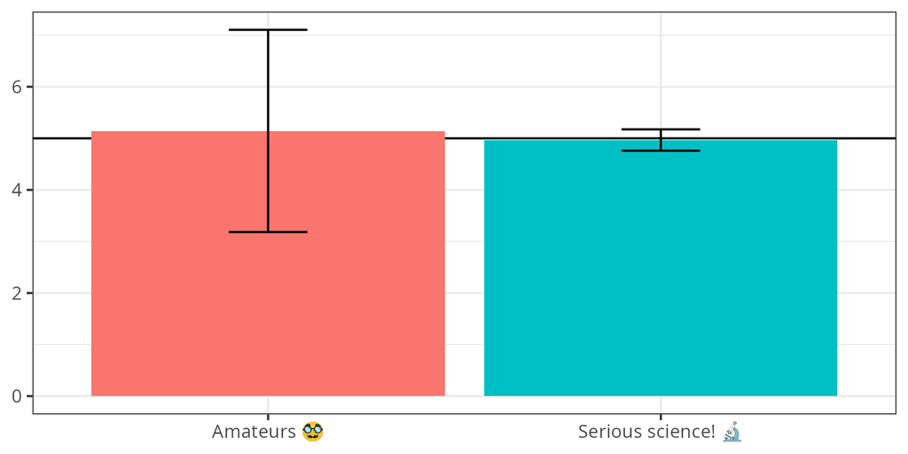

Requires understanding

- what error bars show (variance)
- how the error bar is computed ($\pm 1 \sigma$)
- how that translates to real data (most data within 2*bars)

## Goal(s) of Uncertainty Visualization

Communicate the Legitimacy of Conclusions

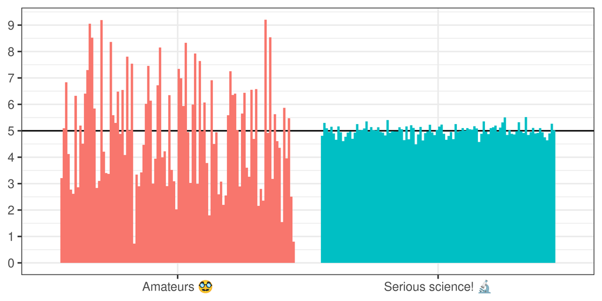

## Goal(s) of Uncertainty Visualization

Transparency

In a survey of 90 “visualization authors” recruited from the InfoVis community, respondents mentioned the

> importance of transparency in presentations of data, suggesting that omitting uncertainty was misleading or even lying. <sup>1</sup>
[^1]: Hullman, Jessica. 2020. “Why Authors Don’t Visualize Uncertainty.” IEEE Transactions on Visualization and Computer Graphics 26(1):130–39. doi:10.1109/TVCG.2019.2934287.

## Goal(s) of Uncertainty Visualization

Making accurate decisions under uncertainty

- Visualizing uncertainty is just the first step
- Ultimate goal: Use the uncertainty to
  - communicate effectively
  - support better decision-making

Requires understanding how we perceive and use charts – whether deterministic or distributional